# SimCRC Chile — Calibration Results

Adenoma Model (Female) · v0.13.0 · April 6, 2026

SimCRC team

## Calibration Overview

**Model:** SimCRC — Adenoma (Female), Chilean population

**Version:** v0.13.0 · Calibrated April 6, 2026

**Method:** BayCANN (Bayesian Calibration with Artificial Neural Networks)

- Priors derived from the **US model**, adjusted per Nicolas’ suggestions
- Modified parameters: `alpha_lesion_adenoma`, hazard rates, preclinical-to-clinical detection probabilities
- Calibration targets from **Chilean epidemiological data**
- **4 MCMC chains** used for posterior sampling

## Prior Ranges — Chile vs USA

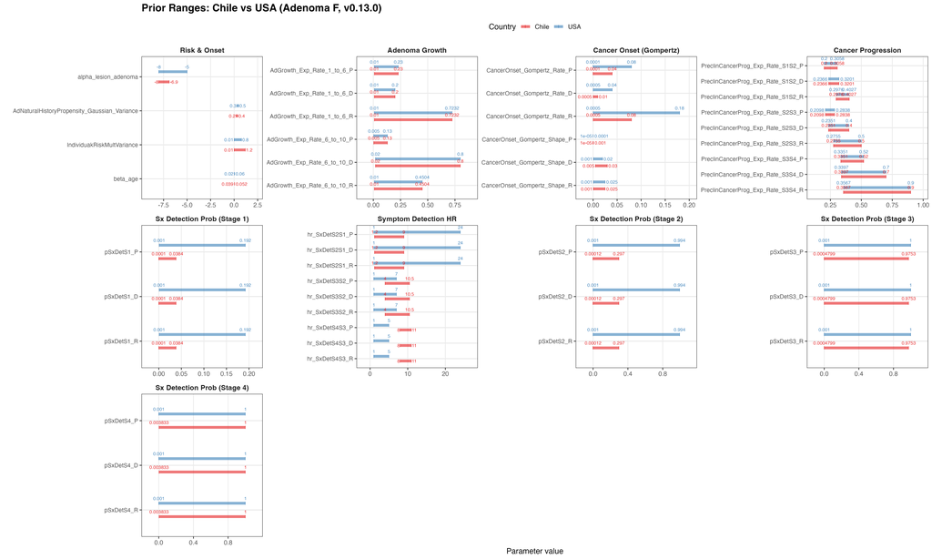

## Posterior Distributions — Chile vs USA

[figure not shown]

## Calibration Targets — Numerical (Chile vs USA)

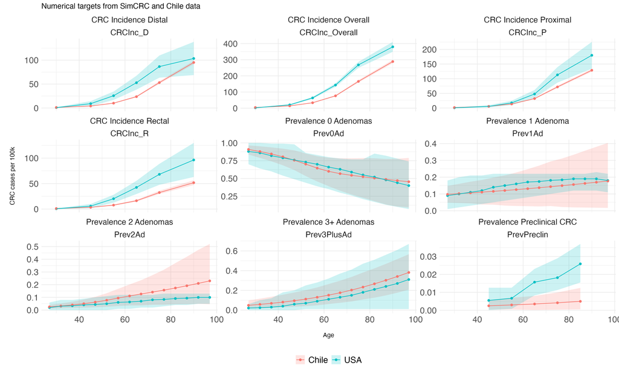

## Calibration Targets — Categorical (Chile vs USA)

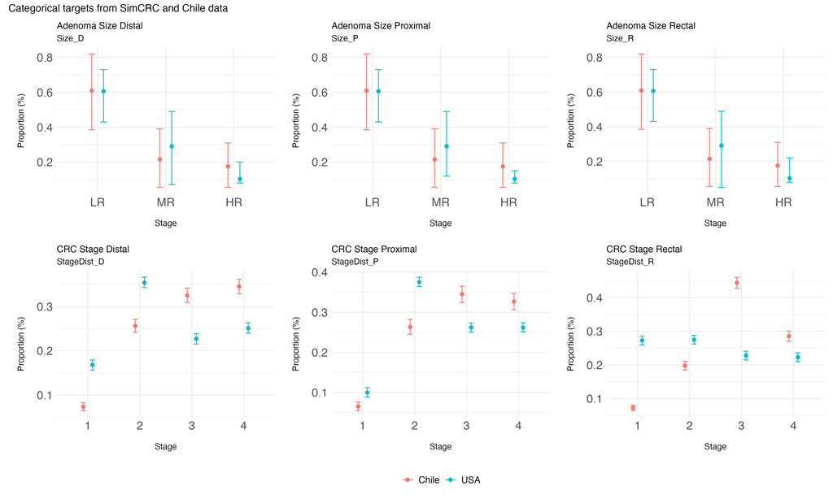

## Coverage Analysis — Numerical Targets

LHS coverage for CRC incidence (overall, proximal, distal, rectal), adenoma prevalence (0–3+ lesions), and preclinical prevalence.

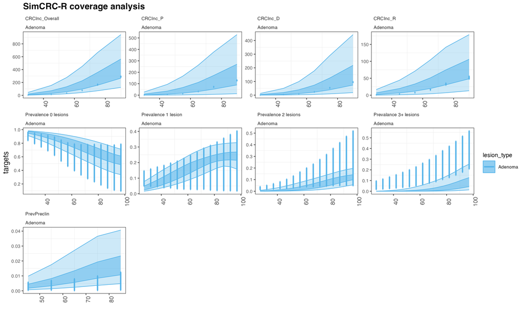

## Coverage Analysis — Categorical Targets

LHS coverage for stage distribution and size distribution by location (proximal, distal, rectal).

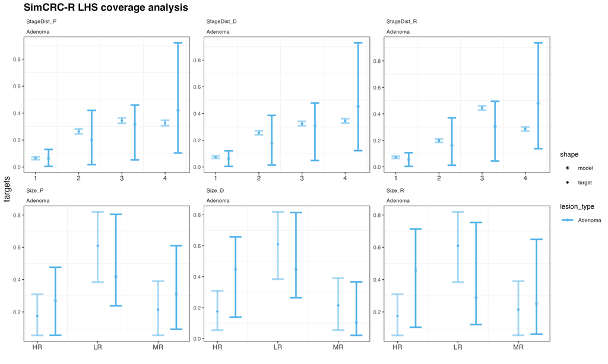

## ANN Prediction Performance

Neural network predicted vs. actual model outputs across all calibration targets.

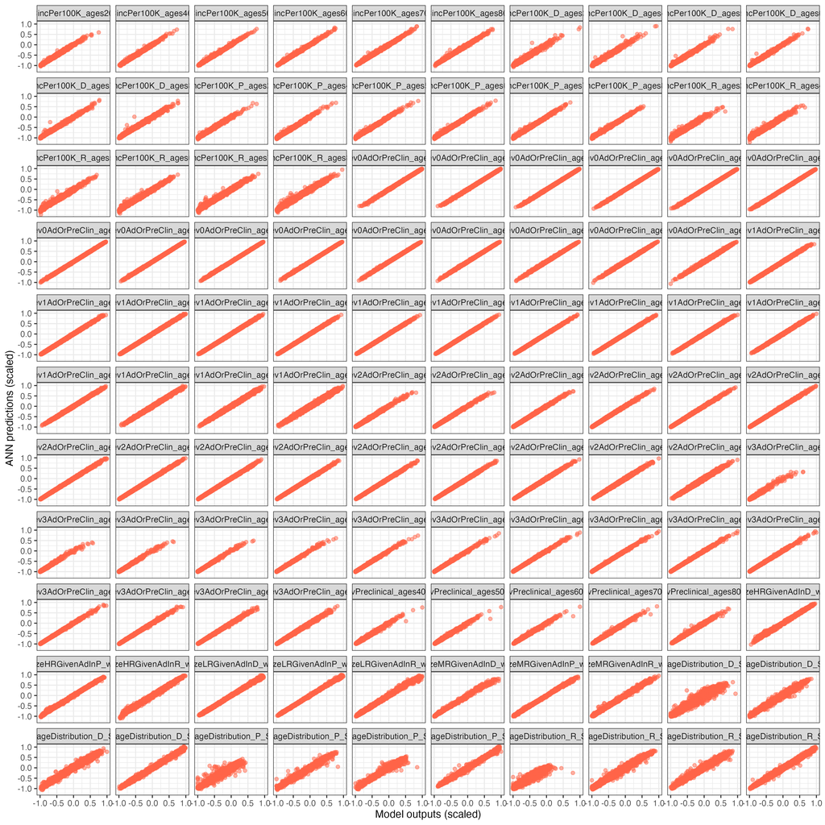

## Prior vs Posterior Distributions

Comparison of prior (purple) and posterior (gold) distributions for all calibrated parameters.

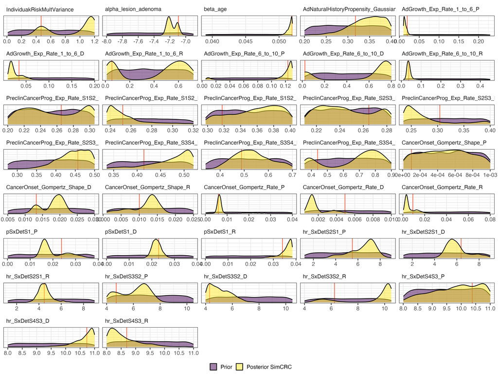

## Posterior Distribution by Chain

Chain-level posterior densities — checking convergence across the 4 MCMC chains.

[figure not shown]

## Internal Validation — Numerical Targets

Posterior validation for CRC incidence and adenoma prevalence targets across age.

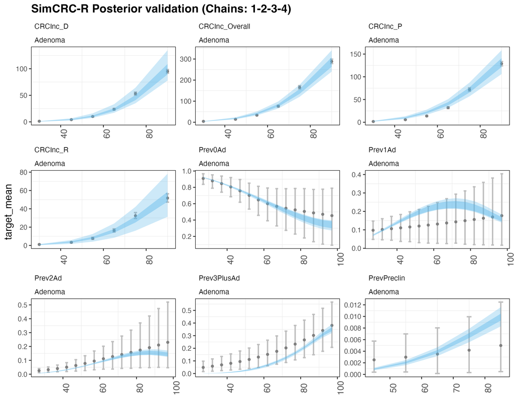

## Internal Validation — Categorical Targets

Posterior validation for size distribution and stage distribution targets.

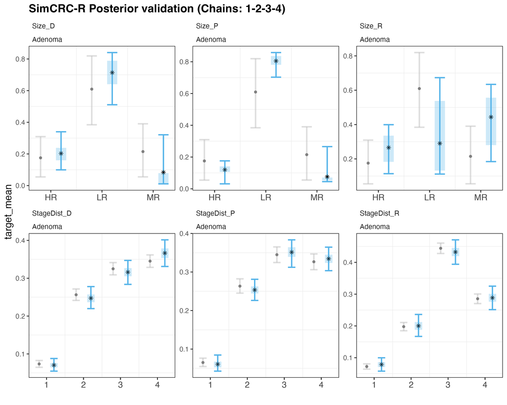

## Internal Validation by Chain

[figure not shown]

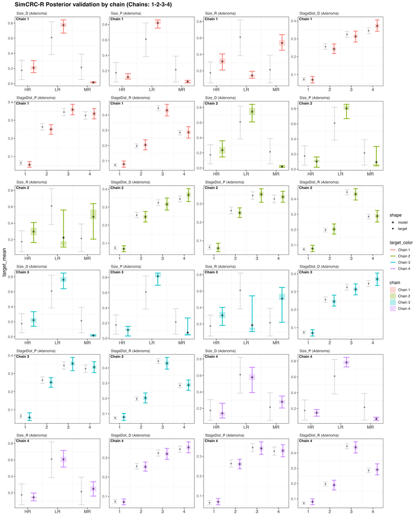

## Calibrated Parameter Set — Numerical (Min Absolute Error)

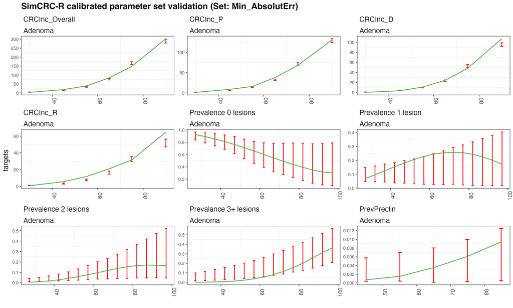

## Calibrated Parameter Set — Categorical (Min Absolute Error)

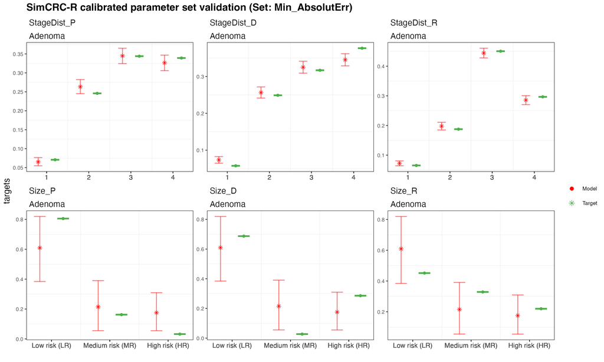

## C++ and SimCRC-R Validation

Validation of C++ and SimCRC-R natural history versions — Chile (v0.13.0) vs USA (v0.12.0), minimum MAE parameter set (Female, 3rd).

[figure not shown]

## Screening Cost Update — v2 vs v3 (CLP)

Updated to 2026 Chilean costs (`screen_costs_v3.csv`). Key changes:

| Procedure | v2 | v3 | Change |
| --- | --- | --- | --- |
| FIT | 14,220 | 21,510 | +51% |
| SIG | 77,100 | 118,064 | +53% |
| Screening colonoscopy (no polypectomy) | 121,664 | 181,271 | +49% |
| Diagnostic colonoscopy (no polypectomy) | 105,885 | 157,762 | +49% |
| Surveillance colonoscopy (no polypectomy) | 119,993 | 178,781 | +49% |
| Colonoscopy with polypectomy | 144,028 | 426,078 | +196% |
| Fatal perforation | 1,134,170 | 3,355,203 | +196% |
| Serious GI complication | 1,134,170 | 3,355,203 | +196% |
| Other GI complication | 808,045 | 2,390,433 | +196% |
| Cardiovascular complication | 885,641 | 2,619,984 | +196% |

## Cost-Effectiveness — All Strategies (v2 vs v3)

**Costs v2**

All Strategies (v2)

WTP = $16M per QALY

|  | Cost (M$) | QALYs | ICER (M$) |
| --- | --- | --- | --- |
| COL5555q100 | 254.7 | 40.5 | — |
| COL5050q100 | 256.7 | 45.9 | 0.38 |
| NoScreening | 263.4 | 0.0 | — |
| COL4545q100 | 267.9 | 48.3 | — |
| FIT5570q3 | 276.5 | 25.5 | — |
| FIT5070q3 | 279.6 | 30.9 | — |
| COL4570q15 | 308.1 | 57.9 | 4.29 |
| COL4575q15 | 332.2 | 59.3 | 17.92 |
| COL4570q10 | 357.0 | 60.5 | 20.07 |
| COL4575q10 | 378.9 | 61.0 | 46.22 |
| COL4570q5 | 500.4 | 61.9 | 125.14 |

**Costs v3**

All Strategies (v3)

WTP = $16M per QALY

|  | Cost (M$) | QALYs | ICER (M$) |
| --- | --- | --- | --- |
| NoScreening | 268.5 | 0.0 | — |
| FIT5570q3 | 339.8 | 25.5 | 2.79 |
| FIT5070q3 | 356.1 | 30.9 | 3.02 |
| COL5555q100 | 398.0 | 40.5 | — |
| COL5050q100 | 410.7 | 45.9 | 3.64 |
| COL4545q100 | 431.5 | 48.3 | 8.61 |
| COL4570q15 | 548.5 | 57.9 | 12.24 |
| COL4575q15 | 604.1 | 59.3 | — |
| COL4570q10 | 649.6 | 60.5 | 39.23 |
| COL4575q10 | 695.8 | 61.0 | 97.60 |
| COL4570q5 | 912.0 | 61.9 | 222.57 |

[figure not shown]

## Cost-Effectiveness — FIT Strategies (v2 vs v3)

**Costs v2**

FIT Strategies (v2)

WTP = $16M per QALY

|  | Cost (M$) | QALYs | ICER (M$) |
| --- | --- | --- | --- |
| NoScreening | 263.4 | 0.0 | — |
| FIT5570q3 | 276.5 | 25.5 | 0.51 |
| FIT5070q3 | 279.6 | 30.9 | 0.58 |
| FIT4570q3 | 290.3 | 37.0 | — |
| FIT5070q2 | 291.1 | 37.5 | 1.74 |
| FIT4570q2 | 304.8 | 42.8 | 2.59 |
| FIT4575q2 | 316.7 | 45.0 | 5.41 |
| FIT4570q1 | 367.0 | 51.6 | 7.64 |
| FIT4575q1 | 383.5 | 52.8 | 13.48 |
| FIT4580q1 | 396.4 | 53.5 | 19.08 |
| FIT4585q1 | 405.2 | 53.7 | 40.83 |

**Costs v3**

FIT Strategies (v3)

WTP = $16M per QALY

|  | Cost (M$) | QALYs | ICER (M$) |
| --- | --- | --- | --- |
| NoScreening | 268.5 | 0.0 | — |
| FIT5570q3 | 339.8 | 25.5 | 2.79 |
| FIT5070q3 | 356.1 | 30.9 | 3.02 |
| FIT4570q3 | 387.4 | 37.0 | 5.14 |
| FIT5070q2 | 394.6 | 37.5 | — |
| FIT4570q2 | 430.1 | 42.8 | 7.33 |
| FIT4575q2 | 455.6 | 45.0 | 11.58 |
| FIT4570q1 | 563.4 | 51.6 | 16.38 |
| FIT4575q1 | 595.8 | 52.8 | 26.56 |
| FIT4580q1 | 620.2 | 53.5 | 36.07 |
| FIT4585q1 | 636.3 | 53.7 | 74.06 |

[figure not shown]

## Cost Breakdown by Component — v2 vs v3

*cost = **events × unit price**. FIT: 14,220→21,510 CLP (+51%). Colonoscopy w/ polypectomy: 144,028→426,078 CLP (+196%). Cancer care: unchanged. FIT + COL + Compl + Cancer care = **Total*** (undiscounted). Dampack discounts Total* at 3%/yr → **Disc. total** (= “Cost” in ICER tables). Yellow = optimal at WTP $16M.*

**All strategies**

All strategies — v2

|  | FIT tests/1k | FIT cost (M$) | COL/1k | COL cost (M$) | Compl (M$) | Cancer care (M$) | Total* (M$) | Disc. total (M$) | ICER (M$) |
| --- | --- | --- | --- | --- | --- | --- | --- | --- | --- |
| COL5555q100 | 0 | 0.0 | 1,818 | 233.5 | 7.1 | 287.4 | 528.0 | 254.7 | — |
| COL5050q100 | 0 | 0.0 | 1,810 | 231.3 | 5.8 | 269.2 | 506.3 | 256.7 | 0.38 |
| NoScreening | 0 | 0.0 | 42 | 0.0 | 1.0 | 729.5 | 730.6 | 263.4 | — |
| COL4545q100 | 0 | 0.0 | 1,781 | 226.3 | 4.9 | 277.1 | 508.2 | 267.9 | — |
| FIT5570q3 | 4,922 | 70.0 | 557 | 69.1 | 3.8 | 516.3 | 659.2 | 276.5 | — |
| FIT5070q3 | 5,959 | 84.7 | 623 | 77.1 | 3.7 | 475.2 | 640.7 | 279.6 | — |
| COL4570q15 | 0 | 0.0 | 2,930 | 375.0 | 8.6 | 153.4 | 537.0 | 308.1 | 4.29 |
| COL4575q15 | 0 | 0.0 | 3,554 | 455.9 | 12.9 | 132.1 | 600.8 | 332.2 | 17.92 |
| COL4570q10 | 0 | 0.0 | 3,772 | 481.9 | 10.7 | 120.0 | 612.6 | 357.0 | 20.07 |
| COL4575q10 | 0 | 0.0 | 4,297 | 549.3 | 13.7 | 109.7 | 672.7 | 378.9 | 46.22 |
| COL4570q5 | 0 | 0.0 | 5,790 | 735.0 | 13.4 | 97.6 | 846.0 | 500.4 | 125.14 |

All strategies — v3

|  | FIT tests/1k | FIT cost (M$) | COL/1k | COL cost (M$) | Compl (M$) | Cancer care (M$) | Total* (M$) | Disc. total (M$) | ICER (M$) |
| --- | --- | --- | --- | --- | --- | --- | --- | --- | --- |
| NoScreening | 0 | 0.0 | 42 | 0.0 | 3.1 | 741.5 | 744.6 | 268.5 | — |
| FIT5570q3 | 4,922 | 105.9 | 557 | 155.6 | 11.1 | 521.7 | 794.4 | 339.8 | 2.79 |
| FIT5070q3 | 5,959 | 128.2 | 623 | 171.1 | 10.9 | 480.4 | 790.6 | 356.1 | 3.02 |
| COL5555q100 | 0 | 0.0 | 1,818 | 485.7 | 21.1 | 290.7 | 797.5 | 398.0 | — |
| COL5050q100 | 0 | 0.0 | 1,810 | 472.1 | 17.2 | 272.9 | 762.2 | 410.7 | 3.64 |
| COL4545q100 | 0 | 0.0 | 1,781 | 453.1 | 14.4 | 281.5 | 749.0 | 431.5 | 8.61 |
| COL4570q15 | 0 | 0.0 | 2,930 | 751.5 | 25.5 | 155.0 | 932.1 | 548.5 | 12.24 |
| COL4575q15 | 0 | 0.0 | 3,554 | 917.0 | 38.2 | 132.9 | 1,088.1 | 604.1 | — |
| COL4570q10 | 0 | 0.0 | 3,772 | 952.0 | 31.8 | 121.0 | 1,104.8 | 649.6 | 39.23 |
| COL4575q10 | 0 | 0.0 | 4,297 | 1,084.5 | 40.7 | 110.3 | 1,235.5 | 695.8 | 97.60 |
| COL4570q5 | 0 | 0.0 | 5,790 | 1,401.4 | 39.7 | 98.2 | 1,539.3 | 912.0 | 222.57 |

**FIT strategies only**

FIT only — v2

|  | FIT tests/1k | FIT cost (M$) | COL/1k | COL cost (M$) | Compl (M$) | Cancer care (M$) | Total* (M$) | Disc. total (M$) | ICER (M$) |
| --- | --- | --- | --- | --- | --- | --- | --- | --- | --- |
| NoScreening | 0 | 0.0 | 42 | 0.0 | 1.0 | 729.5 | 730.6 | 263.4 | — |
| FIT5570q3 | 4,922 | 70.0 | 557 | 69.1 | 3.8 | 516.3 | 659.2 | 276.5 | 0.51 |
| FIT5070q3 | 5,959 | 84.7 | 623 | 77.1 | 3.7 | 475.2 | 640.7 | 279.6 | 0.58 |
| FIT4570q3 | 7,670 | 109.1 | 741 | 92.1 | 4.0 | 425.0 | 630.2 | 290.3 | — |
| FIT5070q2 | 8,747 | 124.4 | 833 | 104.3 | 4.7 | 400.5 | 634.0 | 291.1 | 1.74 |
| FIT4570q2 | 10,521 | 149.6 | 931 | 116.1 | 4.7 | 354.1 | 624.5 | 304.8 | 2.59 |
| FIT4575q2 | 12,271 | 174.5 | 1,066 | 134.0 | 5.9 | 333.4 | 647.8 | 316.7 | 5.41 |
| FIT4570q1 | 18,515 | 263.3 | 1,383 | 172.2 | 6.3 | 242.8 | 684.6 | 367.0 | 7.64 |
| FIT4575q1 | 21,037 | 299.1 | 1,532 | 191.3 | 7.5 | 224.6 | 722.5 | 383.5 | 13.48 |
| FIT4580q1 | 23,064 | 328.0 | 1,649 | 206.3 | 8.8 | 216.6 | 759.7 | 396.4 | 19.08 |
| FIT4585q1 | 24,516 | 348.6 | 1,728 | 216.5 | 10.1 | 215.4 | 790.5 | 405.2 | 40.83 |

FIT only — v3

|  | FIT tests/1k | FIT cost (M$) | COL/1k | COL cost (M$) | Compl (M$) | Cancer care (M$) | Total* (M$) | Disc. total (M$) | ICER (M$) |
| --- | --- | --- | --- | --- | --- | --- | --- | --- | --- |
| NoScreening | 0 | 0.0 | 42 | 0.0 | 3.1 | 741.5 | 744.6 | 268.5 | — |
| FIT5570q3 | 4,922 | 105.9 | 557 | 155.6 | 11.1 | 521.7 | 794.4 | 339.8 | 2.79 |
| FIT5070q3 | 5,959 | 128.2 | 623 | 171.1 | 10.9 | 480.4 | 790.6 | 356.1 | 3.02 |
| FIT4570q3 | 7,670 | 165.0 | 741 | 202.3 | 12.0 | 429.4 | 808.7 | 387.4 | 5.14 |
| FIT5070q2 | 8,747 | 188.1 | 833 | 230.7 | 14.0 | 404.4 | 837.1 | 394.6 | — |
| FIT4570q2 | 10,521 | 226.3 | 931 | 253.1 | 13.9 | 357.7 | 851.0 | 430.1 | 7.33 |
| FIT4575q2 | 12,271 | 263.9 | 1,066 | 294.4 | 17.5 | 335.9 | 911.7 | 455.6 | 11.58 |
| FIT4570q1 | 18,515 | 398.3 | 1,383 | 370.5 | 18.6 | 245.0 | 1,032.3 | 563.4 | 16.38 |
| FIT4575q1 | 21,037 | 452.5 | 1,532 | 413.2 | 22.2 | 226.1 | 1,114.0 | 595.8 | 26.56 |
| FIT4580q1 | 23,064 | 496.1 | 1,649 | 447.5 | 26.1 | 217.6 | 1,187.4 | 620.2 | 36.07 |
| FIT4585q1 | 24,516 | 527.3 | 1,728 | 471.0 | 29.8 | 216.2 | 1,244.3 | 636.3 | 74.06 |

## What Drives the v2 → v3 Cost Increase?

|  | FIT (+51%) Δ M$ | FIT (+51%) % | COL (+116% eff.) Δ M$ | COL (+116% eff.) % | Compl. (+196%) Δ M$ | Compl. (+196%) % | Cancer care (≈0%) Δ M$ | Cancer care (≈0%) % | Δ Total M$ |  |
| --- | --- | --- | --- | --- | --- | --- | --- | --- | --- | --- |
| NoScreening | 0.0 | 0.0% | 0.0 | 0.0% | 2.0 | 14.6% | 12.0 | 85.4% |  | 14.0 |
| FIT5570q3 | 35.9 | 26.5% | 86.5 | 64.0% | 7.4 | 5.4% | 5.4 | 4.0% | 135.2 |  |
| FIT5070q3 | 43.4 | 29.0% | 94.0 | 62.7% | 7.2 | 4.8% | 5.2 | 3.5% | 149.8 |  |
| FIT4570q3 | 55.9 | 31.3% | 110.3 | 61.8% | 7.9 | 4.4% | 4.5 | 2.5% | 178.6 |  |
| FIT5070q2 | 63.8 | 31.4% | 126.4 | 62.2% | 9.2 | 4.5% | 3.8 | 1.9% | 203.2 |  |
| FIT4570q2 | 76.7 | 33.9% | 137.0 | 60.5% | 9.2 | 4.1% | 3.6 | 1.6% | 226.5 |  |
| FIT4575q2 | 89.5 | 33.9% | 160.4 | 60.8% | 11.6 | 4.4% | 2.4 | 0.9% | 263.9 |  |
| FIT4570q1 | 135.0 | 38.8% | 198.3 | 57.0% | 12.3 | 3.5% | 2.2 | 0.6% | 347.8 |  |
| FIT4575q1 | 153.4 | 39.2% | 222.0 | 56.7% | 14.7 | 3.7% | 1.5 | 0.4% | 391.5 |  |
| FIT4580q1 | 168.1 | 39.3% | 241.2 | 56.4% | 17.3 | 4.0% | 1.0 | 0.2% | 427.7 |  |
| FIT4585q1 | 178.7 | 39.4% | 254.6 | 56.1% | 19.7 | 4.3% | 0.8 | 0.2% | 453.8 |  |

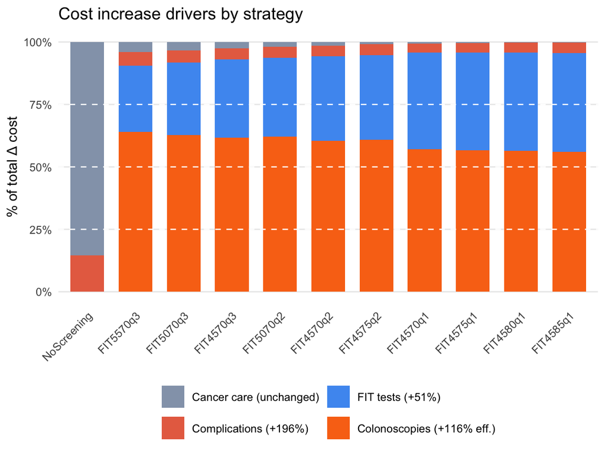

SimCRC

Slide outline

[figure not shown]